# Differential Expression Analyisis with DESEQ2. Isakova et al. 2020

Alvaro Santacruz Roco

20 de mayo, 2022

Para el análisis de este estudio se ha utilizado **R statistical software** (https://cran.r-project.org/index.html). Se ha utilizado la versión más reciente publicada (R 4.2.0). Para poder realizar el análisis es necesario instalar una serie de librerías, algunas estándar de CRAN y otras más específicas para un análisis de datos de secuenciación que son parte del proyecto Bioconductor (versión 3.6).

```r
> # Librerías y paquetes necesarios para el análisis
> # Mediante if() se indica que se instalen los paquetes si no están instalados
> if (!require(Rsubread)) BiocManager::install("Rsubread")
> if (!require(edgeR))BiocManager::install("edgeR")
> if (!require(limma))BiocManager::install("limma")
> if (!require(DESeq2))BiocManager::install("DESeq2")
> if (!require(EnhancedVolcano))BiocManager::install("EnhancedVolcano")
> if (!require(pheatmap))BiocManager::install("pheatmap")
```

# 1. Selección de los datos

Las muestras seleccionadas para el análisis son las siguientes:

Muestras seleccionadas para el análisis

| SampleName | Group |
| --- | --- |
| Lung_F1 | Female |
| Lung_F2 | Female |
| Lung_F3 | Female |
| Lung_M1 | Male |
| Lung_M2 | Male |
| Lung_M3 | Male |

# 2. Preprocesado de los datos

## 2.1. Filtraje de *miRNAs* poco expresados.

En primer lugar es necesario realizar un filtraje de aquellos *miRNAs* que se encuentran poco expresados de acuerdo con los valores de contaje. Estos *miRNAs* son de poca utilidad a la hora de estimar estadísticamente la expresión diferencial de *miRNAs* e influyen en la tasa de falsos positivos que se puede obtener en el análisis.

Para poder realizar el filtraje, los valores de contaje se estandarizan en función del tamaño de la librería de la muestra y así evitar que se atribuyan valores muy bajos a algunos contajes debido a diferencias entre muestras en los tamaños de la librería. Los valores de contaje se expresan como *counts per million* (CPMs).

Para realizar el filtraje de los datos, se eliminan todos aquellos en los que o las muestras de macho o las muestras de hembra, en alguna de sus tres réplicas tenga un valor de contaje igual a 0, de acuerdo con los valores CPM calculados.

## 2.2. Uso de clases específicas para manejar los datos.

Finalmente, para trabajar de forma más eficiente, los valores de contaje filtrados son almacenados en un objeto de la clase S4 de tipo DGEList.

# 3. Exploración y normalización de los datos

## 3.1. Boxplot de los recuentos no normalizados.

Para realizar una primera exploración de los datos del análisis se representa su distribución mediante boxplot. Como los valores de contaje no siguen una distribución normal, en primer lugar es necesario realizar una transformación de los datos utilizando logaritmos. Los valores de contaje son transformados en recuentos *log2* por millón.

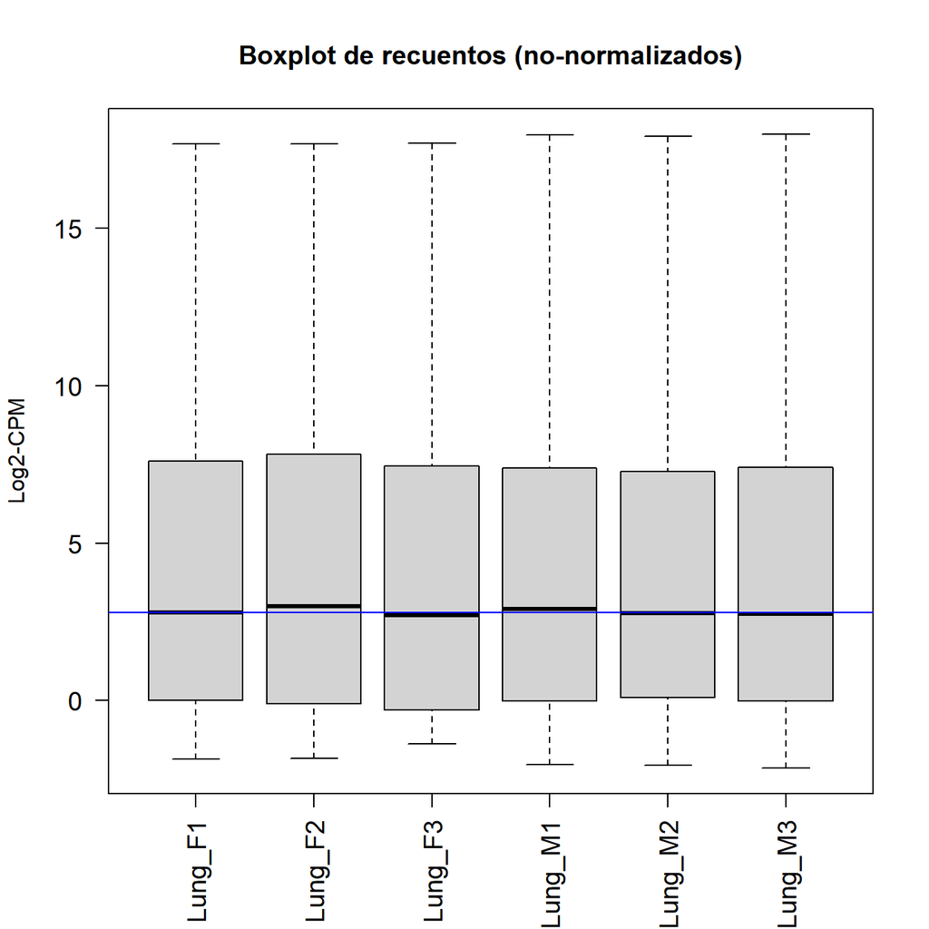

## 3.2. Normalización.

Para normalizar los valores de contaje contenidos en el objeto dgeObj se utiliza la función calcNormFactors. La normalización de los valores permite eliminar los sesgos que puedan existir entre las librerías de cada una de las muestras del análisis. Una vez se obtienen los valores normalizados, la distribución de estos se representa gráficamente mediante boxplot. Nuevamente es necesario transformar los valores mediante logaritmos de la misma forma que se ha indicado anteriormente.

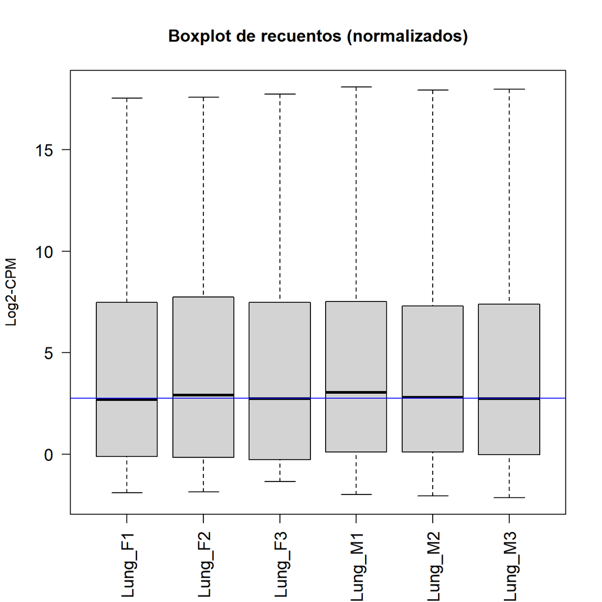

## 3.3. Análisis no supervisado de similaridad entre las muestras.

Para comprobar la similaridad entre muestras y que estas se agrupan correctamente de acuerdo a los grupos establecidos se lleva a cabo un análisis no supervisado de similaridad a partir del cálculo de la matriz de distancias. Esta matriz se calcula mediante la comparación dos a dos de todas las muestras a partir de los valores *log2* por millón normalizados de los recuentos.

La matriz de distancias calculada se visualiza mediante un heatmap. También se realiza un agrupamiento jerárquico a partir de la matriz de distancias y se representa gráficamente.

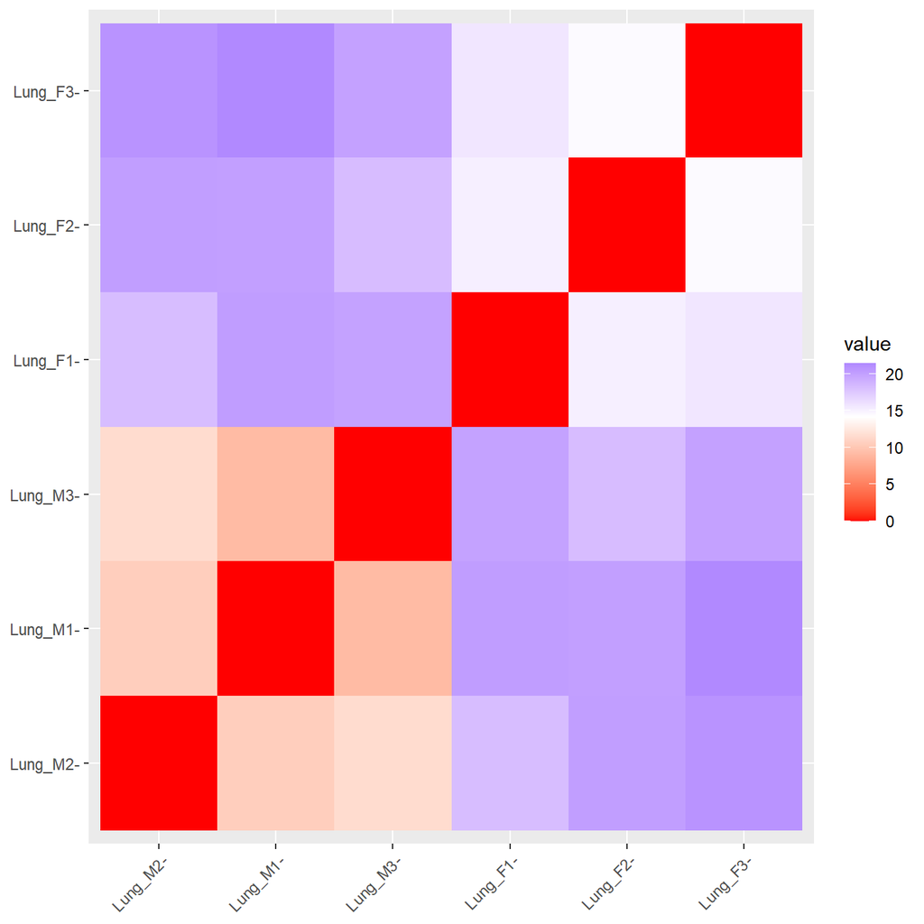

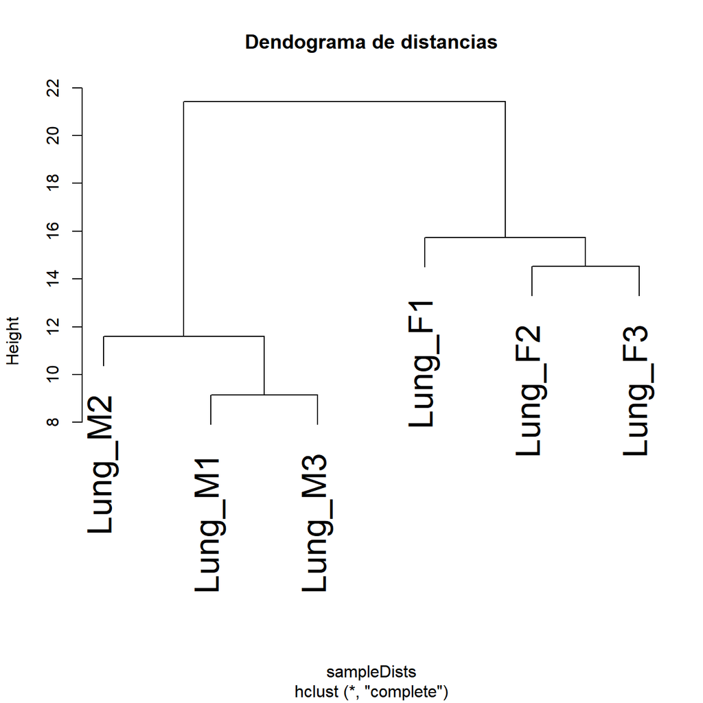

## 3.4. Visualización en dimensión reducida.

Se lleva a cabo también un análisis en dimensión reducida a partir del cálculo de la matriz de distancias.

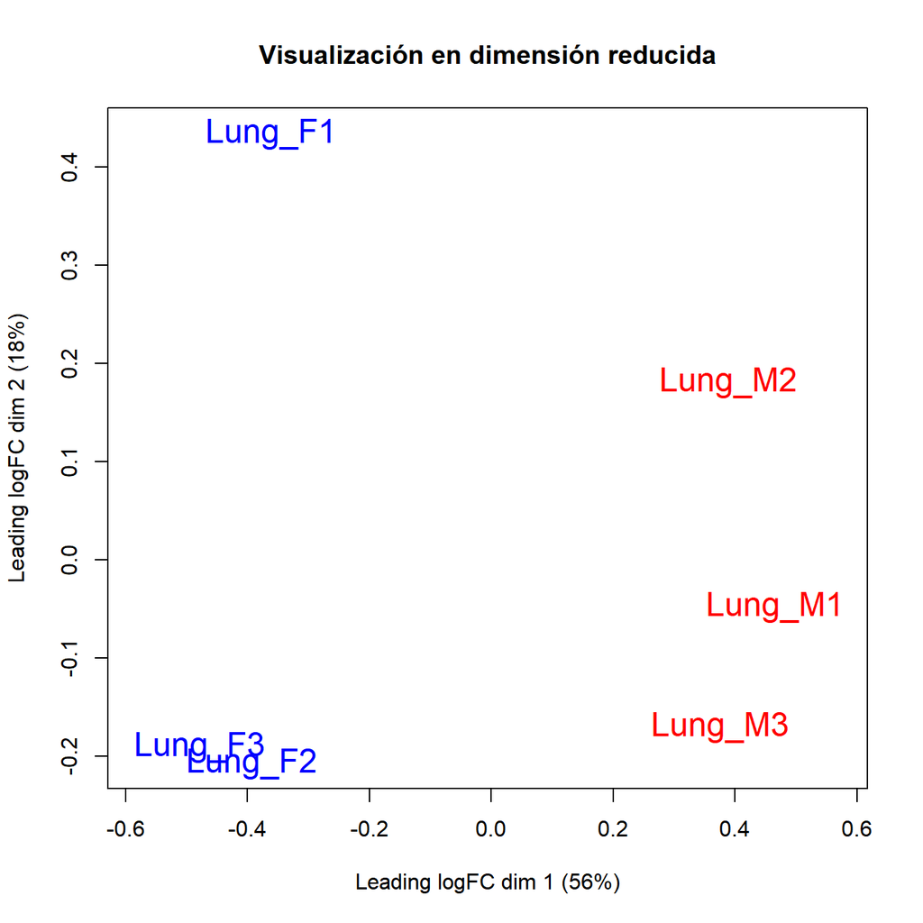

# 4. Análisis de expresión diferencial con *DESEQ2*

## 4.1. Creación del objeto DESeqDataSet y análisis.

Para realizar el análisis de expresión diferencial mediante *DESEQ2* se crea un objeto de tipo DESeqDataSet a partir de los valores de contaje de los transcritos filtrados, con la información sobre los grupos de muestras (macho y hembra).

Este análisis se realiza mediante la función DESeq(), indicando previemente mediante la función relevel() el grupo de referencia a la hora de realizar la comparación (en este caso el grupo referencia es “Hembra”). Finalmente, para facilitar posteriores análisis, la información se guarda en forma de fichero *.csv*.

## 4.2. Selección de *miRNAs* y visualización del perfil de expresión.

La lista de *miRNAs* diferencialmente expresados se visualiza de manera gráfica mediante Volcano plot. Por defecto, en la gráfica aparecen indicados en rojo aquellos *miRNAs* con un *logFC* absoluto mayor de 1 y un *p* valor menor de 0.05.

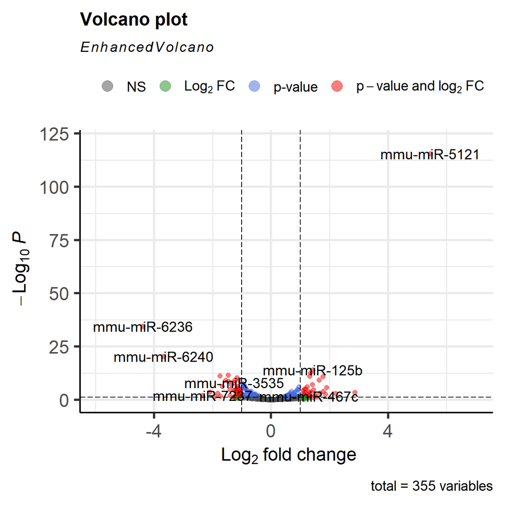

Se selecciona un subconjunto de *miRNAs* diferencialmente expresados de acuerdo con un umbral de *log2FC* y *padj* a partir del conjunto de *miRNAs* diferencialmente expresados. En concreto, se seleccionan aquellos con un *log2FC* absoluto mayor de 1 y un *padj* menor de 0.05.

miRNAs diferencialmente expresados *DESEQ2*: *log2FC* absoluto mayor de 1 y un *p* valor adj menor de 0.05

| Total | Upregulated | Downregulated | No.sig |
| --- | --- | --- | --- |
| 355 | 26 | 33 | 296 |

El perfil de expresión del conjunto de *miRNAs* seleccionados de acuerdo a un *log2FC* absoluto mayor de 1 y un *padj* menor de 0.05 se visualiza a través de un heatmap.

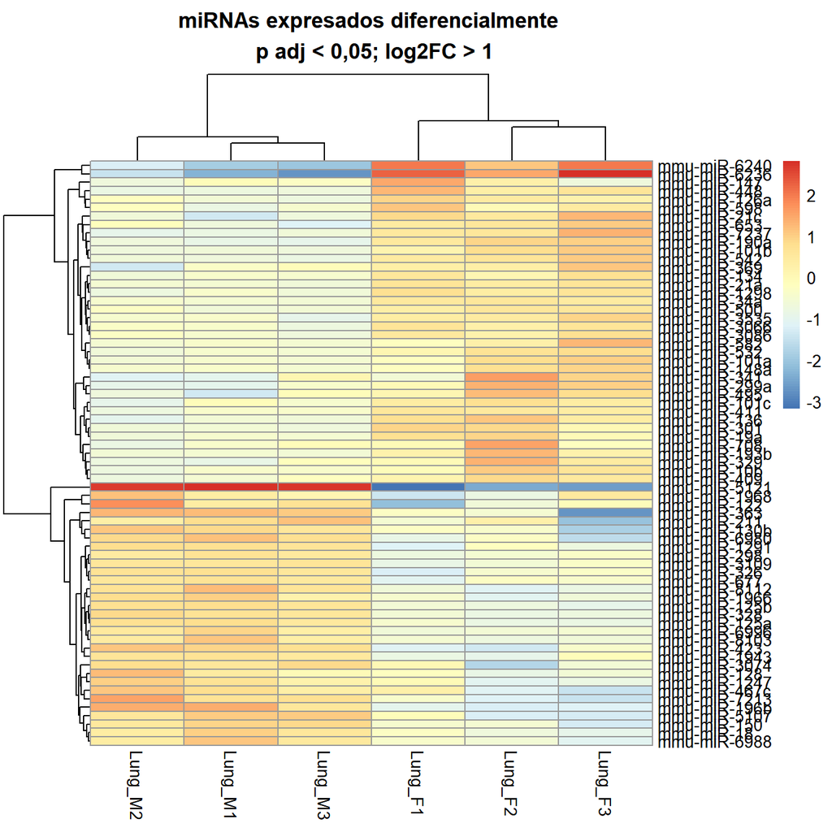